# Coral_Reef_Analysis

Annabelle Mauri

2026-09-02

```r
# read in data with read.csv()
coral <- read.csv("coral_sparse.csv")
```

```r
# cleaning data to facilitate analysis:

# setting factor levels for all categorical variables of interest
# with factor() for characters and as.factor() for integers
coral$sewage_pollution <- factor(coral$sewage_pollution,
                                 levels = c("None", "Low", "Medium", "High"))
coral$industrial_pollution <- factor(coral$industrial_pollution,
                                  levels = c("None", "Low", "Medium", "High"))
coral$siltation <- factor(coral$siltation,
                        levels = c("Never", "Occasionally", "Often", "Always"))
# trash loaded in as an integer but is actually a categorical variable
coral$trash_general <- as.factor(coral$trash_general)

# changing the factor names of trash_general
levels(coral$trash_general) <- c("None", "Low", "Medium", "High")

# creating a new variable that sums all incidences of disease with mutate()
coral <- coral %>%
  mutate("disease_count" = black_band + white_band +
           white_plague + aspergillosis)
```

```r
# keeping rows that contain data for bleaching_percent_pop with subset()
bleached_coral <- coral %>%
  subset(bleaching_percent_pop!=is.na(bleaching_percent_pop))

# keeping rows that contain data for disease_count
diseased_coral <- coral %>%
  subset(disease_count!=is.na(disease_count))
```

Part 1: Relationships between Pollutants and Coral Bleaching

```r
# first remove rows with no data for sewage_pollution using subset()
coral_sewage <- bleached_coral %>%
  subset(sewage_pollution!="")

# performing an ANOVA to compare the mean bleaching percents at
# different levels of sewage pollution with aov()
sewage_anova <- aov(bleaching_percent_pop ~ sewage_pollution,
                    data = coral_sewage)
summary(sewage_anova)
```

```
##                    Df  Sum Sq Mean Sq F value Pr(>F)
## sewage_pollution    3    4175  1391.6   3.433 0.0163 *
## Residuals        2837 1149914   405.3
## ---
## Signif. codes:  0 '***' 0.001 '**' 0.01 '*' 0.05 '.' 0.1 ' ' 1
```

```r
# since the results were significant, performing a Tukey's post hoc test
# with TukeyHSD()
TukeyHSD(sewage_anova)
```

```
##   Tukey multiple comparisons of means
##     95% family-wise confidence level
##
## Fit: aov(formula = bleaching_percent_pop ~ sewage_pollution, data = coral_sewage)
##
## $sewage_pollution
##                   diff        lwr      upr     p adj
## Low-None    -1.2024284 -3.3312238 0.926367 0.4669909
## Medium-None  2.1970974 -1.1368128 5.531008 0.3269626
## High-None    2.5993699 -2.3156379 7.514378 0.5250323
## Medium-Low   3.3995258  0.1544407 6.644611 0.0358554
## High-Low     3.8017983 -1.0533971 8.656994 0.1833980
## High-Medium  0.4022725 -5.0891854 5.893730 0.9976328
```

**Analysis of variance revealed a significant difference between levels of sewage pollution and coral bleaching (F(3, 2837) = 3.433, p = 0.016). Therefore, we reject the null hypothesis of no relationship between sewage level and coral bleaching. Using a Tukey’s post hoc test, we determined that reefs with medium levels of sewage had significantly greater levels of coral bleaching than reefs with low levels of sewage pollution (p = 0.036). Other pairwise comparisons were not statistically significant.**

```r
# first remove rows with no data for industrial_pollution using subset()
coral_industrial <- bleached_coral %>%
  subset(industrial_pollution!="")

# performing an ANOVA to compare the mean bleaching percents at
# different levels of industrial pollution
industrial_anova <- aov(bleaching_percent_pop ~ industrial_pollution,
                        data = coral_industrial)
summary(industrial_anova)
```

```
##                        Df  Sum Sq Mean Sq F value  Pr(>F)
## industrial_pollution    3    4997  1665.8   4.129 0.00624 **
## Residuals            2840 1145700   403.4
## ---
## Signif. codes:  0 '***' 0.001 '**' 0.01 '*' 0.05 '.' 0.1 ' ' 1
```

```r
# since the results were significant, performing a Tukey's post hoc test
# with TukeyHSD()
TukeyHSD(industrial_anova)
```

```
##   Tukey multiple comparisons of means
##     95% family-wise confidence level
##
## Fit: aov(formula = bleaching_percent_pop ~ industrial_pollution, data = coral_industrial)
##
## $industrial_pollution
##                 diff         lwr       upr     p adj
## Low-None    1.058117 -1.30934682  3.425580 0.6591739
## Medium-None 4.582241  0.05643869  9.108042 0.0459020
## High-None   7.301665 -0.65431909 15.257649 0.0853614
## Medium-Low  3.524124 -1.32117547  8.369423 0.2414150
## High-Low    6.243548 -1.89842478 14.385522 0.1991637
## High-Medium 2.719424 -6.28999985 11.728849 0.8653887
```

**Analysis of variance revealed a statistically significant difference in coral bleaching at different levels of industrial pollution (F(3, 2840) = 4.129, p = 0.0062). This allowed us to reject our null hypothesis of no difference in coral bleaching at different industrial pollution levels. Using a Tukey’s post-hoc test, we determined that coral reefs with medium levels of industrial pollution exhibited significantly higher levels of coral bleaching than reefs with none (p = 0.046). Other pairwise comparisons were not significant.**

```r
# first remove rows with no data for siltation using subset()
coral_silt <- bleached_coral %>%
  subset(siltation!="")

# performing an ANOVA to compare the mean bleaching percents at
# different levels of siltation
silt_anova <- aov(bleaching_percent_pop ~ siltation, data = coral_silt)
summary(silt_anova)
```

```
##               Df  Sum Sq Mean Sq F value   Pr(>F)
## siltation      3    9047    3016   7.337 6.74e-05 ***
## Residuals   2856 1173875     411
## ---
## Signif. codes:  0 '***' 0.001 '**' 0.01 '*' 0.05 '.' 0.1 ' ' 1
```

```r
# since the results were significant, performing a Tukey's post hoc test
# with TukeyHSD()
TukeyHSD(silt_anova)
```

```
##   Tukey multiple comparisons of means
##     95% family-wise confidence level
##
## Fit: aov(formula = bleaching_percent_pop ~ siltation, data = coral_silt)
##
## $siltation
##                           diff         lwr        upr     p adj
## Occasionally-Never  -2.1147226 -4.44177056  0.2123254 0.0902275
## Often-Never          0.2473641 -2.81604726  3.3107755 0.9968386
## Always-Never         5.0495507  0.52873185  9.5703695 0.0214379
## Often-Occasionally   2.3620867 -0.40593199  5.1301054 0.1252117
## Always-Occasionally  7.1642733  2.83816172 11.4903848 0.0001257
## Always-Often         4.8021865  0.03935356  9.5650195 0.0472518
```

**Analysis of variance revealed a statistically significant difference in coral bleaching at different levels of siltation in the Caribbean (F(3, 2856) = 7.337, p < 0.0011). Using a Tukey’s post-hoc test, we observed that reefs that always had siltation had significantly greater coral bleaching than reefs that never experienced siltation (p = 0.021), reefs that occasionally experienced siltation (p < 0.001), and reefs that often experienced siltation (p = 0.047). There were no statistically significant differences in coral bleaching between other levels of siltation.**

```r
# first remove rows with no data for trash_general using subset()
coral_trash <- bleached_coral %>%
  subset(trash_general!="")
```

```r
# now run an ANOVA on the relationship between trash level and coral bleaching
trash_anova_bleach <- aov(bleaching_percent_pop ~ trash_general,
                          data = coral_trash)
summary(trash_anova_bleach)
```

```
##                 Df  Sum Sq Mean Sq F value Pr(>F)
## trash_general    3    2011   670.2   1.578  0.193
## Residuals     3065 1302111   424.8
```

**Analysis of variance revealed no statistically significant difference in coral bleaching between varying levels of trash (F(3, 3065) = 1.578, p = 0.193). Therefore we fail to reject the null hypothesis of no relationship between trash and bleaching.**

Part 1.1: Visualizing Pollution Impacts on Coral Bleaching

```r
# defining pairwise relationships with list() that previous analysis
# showed to be significant
sewage_pairs_sig <- list(c("Medium", "Low"))
industrial_pairs_sig <- list(c("None", "Medium"))
silt_pairs_sig <- list(c("Always", "Never"), c("Always", "Occasionally"),
                       c("Always", "Often"))
```

```r
# plot for sewage pollution & bleaching using ggbarplot()
# and adding asterisks for statistical significance with stat_compare_means()
sewage_plot_1 <- ggbarplot(coral_sewage,
          x = "sewage_pollution",
          y = "bleaching_percent_pop",
          color = "black",
          fill = "aquamarine",
          add = "mean_se",
          ylim = c(0,30)) +
  labs(x = "Sewage", y = "Bleaching Percent") +
  rotate_x_text(angle = 33) +
  stat_compare_means(comparisons = sewage_pairs_sig,
                     method = "t.test",
                     p.adjust.methods = "tukey_hsd",
                     label = "p.signif",
                     label.y = c(20),
                     tip.length = 0.01) +
  theme(text = element_text(size = 10))

# plot for industrial pollution & bleaching
industrial_plot_1 <- ggbarplot(coral_industrial,
          x = "industrial_pollution",
          y = "bleaching_percent_pop",
          color = "black",
          fill = "cornflowerblue",
          add = "mean_se",
          ylim = c(0,30)) +
  labs(x = "Industrial Pollution", y = "") +
  rotate_x_text(angle = 33) +
  stat_compare_means(comparisons = industrial_pairs_sig,
                     method = "t.test",
                     p.adjust.methods = "tukey_hsd",
                     label = "p.signif",
                     label.y = c(20),
                     tip.length = 0.01) +
  theme(text = element_text(size = 10))

# plot for siltation & bleaching
siltation_plot_1 <- ggbarplot(coral_silt,
          x = "siltation",
          y = "bleaching_percent_pop",
          color = "black",
          fill = "darkslategray",
          add = "mean_se",
          ylim = c(0,30)) +
  labs(x = "Siltation", y = "") +
  rotate_x_text(angle = 33) +
  stat_compare_means(comparisons = silt_pairs_sig,
                     method = "t.test",
                     p.adjust.methods = "tukey_hsd",
                     label = "p.signif",
                     label.y = c(25, 22, 19),
                     tip.length = 0.01) +
  theme(text = element_text(size = 10))

# plot for trash & bleaching
trash_plot_1 <- ggbarplot(coral_trash,
          x = "trash_general",
          y = "bleaching_percent_pop",
          color = "black",
          fill = "deepskyblue4",
          add = "mean_se",
          ylim = c(0, 30)) +
  labs(x = "Trash", y = "") +
  rotate_x_text(angle=33) +
  theme(text = element_text(size = 10))
  # no need for stat_compare_means since not significant
```

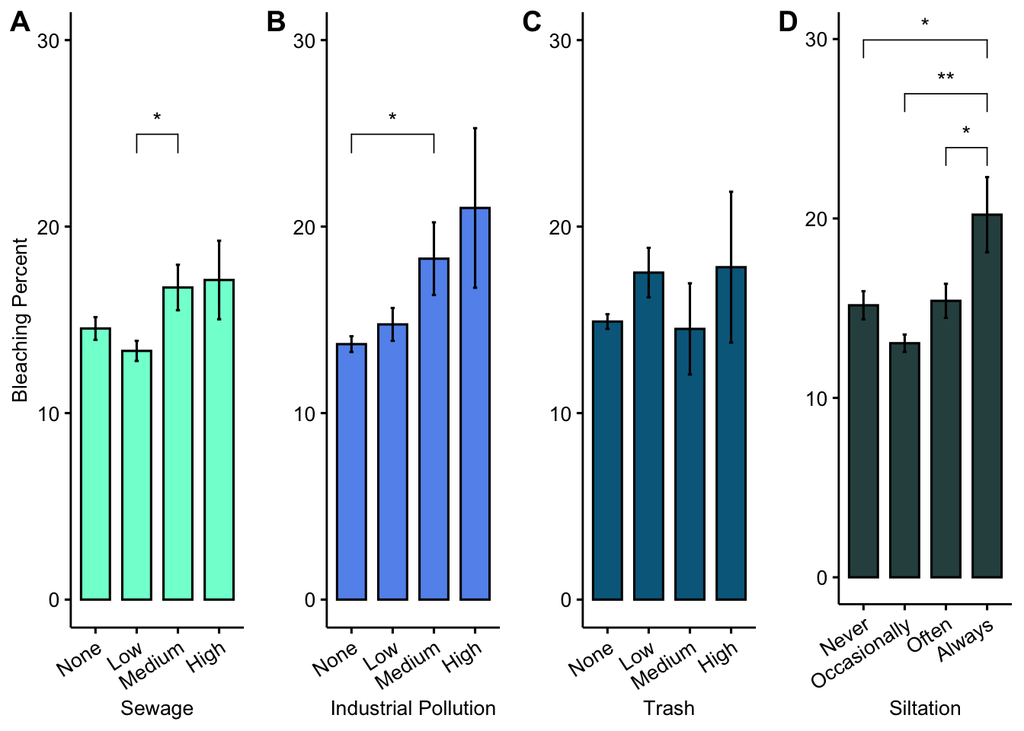

```r
# arranging these plots on panels next to each other with ggarrange()
# this plot will go into my Science report (Figure 2)
ggarrange(sewage_plot_1, industrial_plot_1, trash_plot_1, siltation_plot_1,
          ncol = 4, nrow = 1,
          labels = c("A", "B", "C", "D"))
```

**Figure 2: Average Coral Bleaching by Pollution Level.** Analysis of variance showed a statistically significant difference in coral bleaching by level of sewage pollution (F(3, 2837) = 3.43, p = 0.016), industrial pollution (F(3, 2840) = 4.13, p = 0.0062), and siltation (F(3, 2856) = 7.34, p < 0.001). There was no statistically significant difference in coral bleaching by varying levels of trash (F(3, 3065) = 1.578, p = 0.193). Tukey’s post hoc tests revealed that coral reefs with medium sewage pollution had significantly more coral bleaching than reefs with low sewage pollution (p = 0.036). Additionally, reefs with medium industrial pollution had significantly more coral bleaching than reefs with none (p = 0.046). Finally, coral reefs that always experienced siltation had significantly greater bleaching than reefs that experienced siltation often (p = 0.047), occasionally (p < 0.001), or never (p = 0.021). Error bars indicate standard error. * indicates statistical significance at p < 0.05 and ** at p < 0.01.

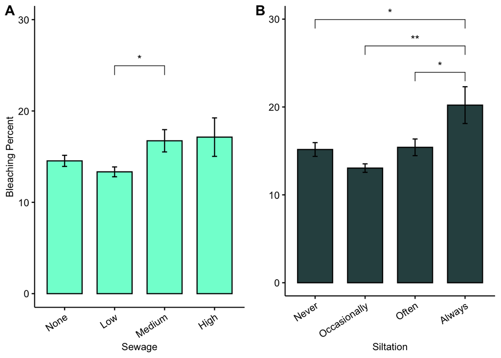

```r
# pared down version of this graph for the graphical abstract
ggarrange(sewage_plot_1, siltation_plot_1, ncol = 2, nrow = 1,
          labels = c("A", "B"))
```

Part 1.2: Impact of pollution on coral disease incidence

```r
# first remove rows with no data for sewage_pollution using subset()
coral_sewage_2 <- diseased_coral %>%
  subset(sewage_pollution!="")

# perform an ANOVA to compare mean disease incidence
# at different levels of sewage pollution
sewage_anova_2 <- aov(disease_count ~ sewage_pollution, data = coral_sewage_2)
summary(sewage_anova_2)
```

```
##                   Df Sum Sq Mean Sq F value  Pr(>F)
## sewage_pollution   3   6676  2225.2   4.642 0.00317 **
## Residuals        781 374340   479.3
## ---
## Signif. codes:  0 '***' 0.001 '**' 0.01 '*' 0.05 '.' 0.1 ' ' 1
```

```r
# now run a Tukey's post-hoc test since the p-value was significant
TukeyHSD(sewage_anova_2)
```

```
##   Tukey multiple comparisons of means
##     95% family-wise confidence level
##
## Fit: aov(formula = disease_count ~ sewage_pollution, data = coral_sewage_2)
##
## $sewage_pollution
##                 diff        lwr       upr     p adj
## Low-None    3.197893 -1.4351151  7.830901 0.2851605
## Medium-None 8.123681  1.5332077 14.714154 0.0084958
## High-None   9.264370  0.1798473 18.348893 0.0436503
## Medium-Low  4.925788 -1.2365895 11.088165 0.1680074
## High-Low    6.066477 -2.7124245 14.845378 0.2841687
## High-Medium 1.140689 -8.8111288 11.092507 0.9910578
```

**Analysis of variance revealed a significant difference between levels of sewage pollution and coral disease incidence (F(3, 781) = 4.642, p = 0.0032). Therefore, we reject the null hypothesis of no relationship between sewage level and coral disease. A Tukey’s post hoc test showed that medium levels of sewage pollution had significantly greater disease incidence than reefs with no sewage pollution (p = 0.0085). Similarly, reefs with high levels of sewage pollution had significantly greater disease incidence than reefs with none (p = 0.0437). Other pairwise comparisons were not statistically significant.**

```r
# first remove rows with no data for industrial_pollution using subset()
coral_industrial_2 <- diseased_coral %>%
  subset(industrial_pollution!="")
```

```r
# after noticing the small sample size in the high category:
# perform a Shapiro-Wilk's test to assess normality with shapiro.test()
shapiro.test(diseased_coral$disease_count[diseased_coral$industrial_pollution==
                                            "High"])
```

```
##
##  Shapiro-Wilk normality test
##
## data:  diseased_coral$disease_count[diseased_coral$industrial_pollution == "High"]
## W = 0.73964, p-value = 0.000478
```

```r
# use a Kruskal-Wallis test to replace the ANOVA
kruskal.test(disease_count ~ industrial_pollution, data = coral_industrial_2)
```

```
##
##  Kruskal-Wallis rank sum test
##
## data:  disease_count by industrial_pollution
## Kruskal-Wallis chi-squared = 6.2941, df = 3, p-value = 0.09815
```

**A Kruskal-Wallis rank sum test did not indicate a statistically significant difference in median disease incidence by level of industrial pollution (H(3) = 6.29, p = 0.098). Therefore, we do not reject the null hypothesis of no difference in the median level of disease between the four levels of industrial pollution.**

```r
# first remove rows with no data for siltation using subset()
coral_silt_2 <- diseased_coral %>%
  subset(siltation!="")

# perform an ANOVA to compare mean disease incidence
# at different levels of siltation
silt_anova_2 <- aov(disease_count ~ siltation, data = coral_silt_2)
summary(silt_anova_2)
```

```
##              Df Sum Sq Mean Sq F value   Pr(>F)
## siltation     3  27439    9146   19.96 1.74e-12 ***
## Residuals   802 367472     458
## ---
## Signif. codes:  0 '***' 0.001 '**' 0.01 '*' 0.05 '.' 0.1 ' ' 1
```

```r
# Tukey's test since the ANOVA was significant
TukeyHSD(silt_anova_2)
```

```
##   Tukey multiple comparisons of means
##     95% family-wise confidence level
##
## Fit: aov(formula = disease_count ~ siltation, data = coral_silt_2)
##
## $siltation
##                          diff        lwr       upr     p adj
## Occasionally-Never   3.995949 -0.3203663  8.312264 0.0810942
## Often-Never         10.451555  3.0631868 17.839923 0.0016379
## Always-Never        23.097984 15.0088832 31.187084 0.0000000
## Often-Occasionally   6.455606 -0.6723021 13.583514 0.0917903
## Always-Occasionally 19.102035 11.2501154 26.953954 0.0000000
## Always-Often        12.646429  2.7666492 22.526208 0.0056517
```

**Analysis of variance revealed a statistically significant difference in coral disease incidence at varying levels of siltation (F(3, 802) = 19.96, p < 0.0001).Tukey’s post hoc testing showed that reefs that always experience siltation have significantly higher rates of coral disease than reefs that often have siltation (p = 0.0057), occasionally have siltation (p < 0.0001), and never have siltation (p < 0.0001). Similarly, reefs that often have siltation also have significantly higher levels of coral disease than reefs that never experience siltation (p = 0.0016).**

```r
# first remove rows with no data for trash_general using subset()
coral_trash_2 <- diseased_coral %>%
  subset(trash_general!="")
```

```r
# now run an ANOVA on the relationship between trash level and disease incidence
trash_anova_disease <- aov(disease_count ~ trash_general, data = coral_trash_2)
summary(trash_anova_disease)
```

```
##                Df Sum Sq Mean Sq F value Pr(>F)
## trash_general   3   3931  1310.3   2.897 0.0342 *
## Residuals     944 426915   452.2
## ---
## Signif. codes:  0 '***' 0.001 '**' 0.01 '*' 0.05 '.' 0.1 ' ' 1
```

```r
# since it was statistically significant, we will run a Tukey's post-hoc test
TukeyHSD(trash_anova_disease)
```

```
##   Tukey multiple comparisons of means
##     95% family-wise confidence level
##
## Fit: aov(formula = disease_count ~ trash_general, data = coral_trash_2)
##
## $trash_general
##                    diff         lwr       upr     p adj
## Low-None      5.9437633  -0.2310223 12.118549 0.0641382
## Medium-None   5.3866512  -4.4776504 15.250953 0.4962394
## High-None    -4.1215724 -16.8239715  8.580827 0.8377715
## Medium-Low   -0.5571121 -11.8724274 10.758203 0.9992731
## High-Low    -10.0653358 -23.9247317  3.794060 0.2421303
## High-Medium  -9.5082237 -25.3593853  6.342938 0.4117122
```

**Analysis of variance revealed a significant relationship between trash level and disease incidence (F(3, 944) = 2.897, p = 0.0342). However, a Tukey’s post hoc test returned no statistically significant pairwise relationships, likely because Tukey’s tests adjust the p-value threshold to avoid inflating Type 1 error. However, coral disease with low levels of trash was notably higher than with no trash and appeared to be trending towards significance (p = 0.064). This likely accounts for the ANOVA being statistically significant.**

```r
# listing significant pairwise relationships for pollution & disease incidence
sewage_pairs_sig_2 <- list(c("Medium", "None"), c("High", "None"))
# no significant pairs for industrial pollution & coral disease or trash
silt_pairs_sig_2 <- list(c("Always", "Never"), c("Always", "Occasionally"),
                         c("Always", "Often"), c("Often", "Never"))
```

```r
# plot for sewage pollution & disease incidence using ggbarplot()
# and stat_compare_means() to add symbols for significance
sewage_plot_2 <- ggbarplot(coral_sewage_2,
          x = "sewage_pollution",
          y = "disease_count",
          color = "black",
          fill = "aquamarine",
          add = "mean_se",
          ylim = c(0,50)) +
  labs(x = "Sewage", y = "Disease Incidence") +
  rotate_x_text(angle = 33) +
  stat_compare_means(comparisons = sewage_pairs_sig_2,
                     method = "t.test",
                     p.adjust.methods = "tukey_hsd",
                     label = "p.signif",
                     label.y = c(30, 34),
                     tip.length = 0.01) +
  theme(text = element_text(size = 10))

# plot for industrial pollution & disease
industrial_plot_2 <- ggbarplot(coral_industrial_2,
          x = "industrial_pollution",
          y = "disease_count",
          color = "black",
          fill = "cornflowerblue",
          add = "mean_se",
          ylim = c(0,50)) +
  labs(x = "Industrial Pollution", y = "") +
  rotate_x_text(angle = 33) +
  theme(text = element_text(size = 10))
  # no need for stat_compare_means since not significant

# plot for siltation & disease
siltation_plot_2 <- ggbarplot(coral_silt_2,
          x = "siltation",
          y = "disease_count",
          color = "black",
          fill = "darkslategray",
          add = "mean_se",
          ylim = c(0,50)) +
  labs(x = "Siltation", y = "") +
  rotate_x_text(angle = 33) +
  stat_compare_means(comparisons = silt_pairs_sig_2,
                     method = "t.test",
                     p.adjust.methods = "tukey_hsd",
                     label = "p.signif",
                     label.y = c(44, 41, 38),
                     tip.length = 0.01) +
  theme(text = element_text(size = 10))

# plot for trash & disease
trash_plot_2 <- ggbarplot(coral_trash_2,
          x = "trash_general",
          y = "disease_count",
          color = "black",
          fill = "deepskyblue4",
          add = "mean_se",
          ylim = c(0, 30)) +
  labs(x = "Trash", y = "") +
  rotate_x_text(angle=33) +
  theme(text = element_text(size = 10))
  # no need for stat_compare_means since not significant
```

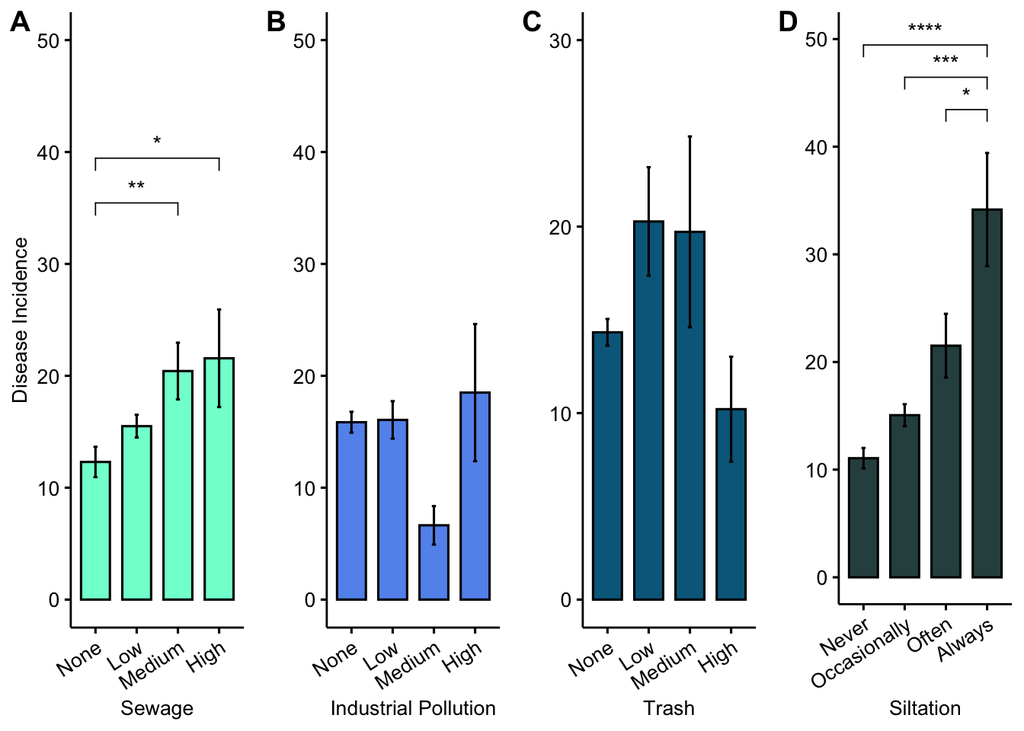

```r
# put all plots together on different panels with ggarrange() for Science report
# (Figure 3)
ggarrange(sewage_plot_2, industrial_plot_2, trash_plot_2, siltation_plot_2,
          ncol = 4, nrow = 1,
          labels = c("A", "B", "C", "D"))
```

**Figure 3: Average Coral Disease Incidence by Pollution Level.** Analysis of variance revealed a statistically significant difference in coral disease incidence according to level of sewage pollution (F(3, 781) = 4.64, p = 0.0032), trash (F(3, 944) = 2.897, p = 0.034), and siltation (F(3, 802) = 19.96, p < 0.0001). Industrial pollution, measured with a Kruskal-Wallis chi-squared test, was not statistically significant (H(3) = 6.29, p = 0.098).Tukey’s post hoc tests showed that reefs with no sewage pollution had significantly less disease incidence than reefs with medium sewage (p = 0.0085) and high sewage (p = 0.044). Reefs that always experienced siltation had significantly higher levels of disease incidence than reefs that often had siltation (p = 0.0057), occasionally (p < 0.0001), and never (p < 0.0001). However, post hoc testing returned no statistically significant pairwise relationships for trash and coral disease rates, likely due to the adjusted p-value thresholds. However, reefs with low levels of trash had greater disease incidence than reefs with none, and this appeared to be the relationship trending towards significance (p = 0.064). Error bars indicate standard error. * indicates statistical significance at p < 0.05 , ** at p < 0.01, and *** at p < 0.001.

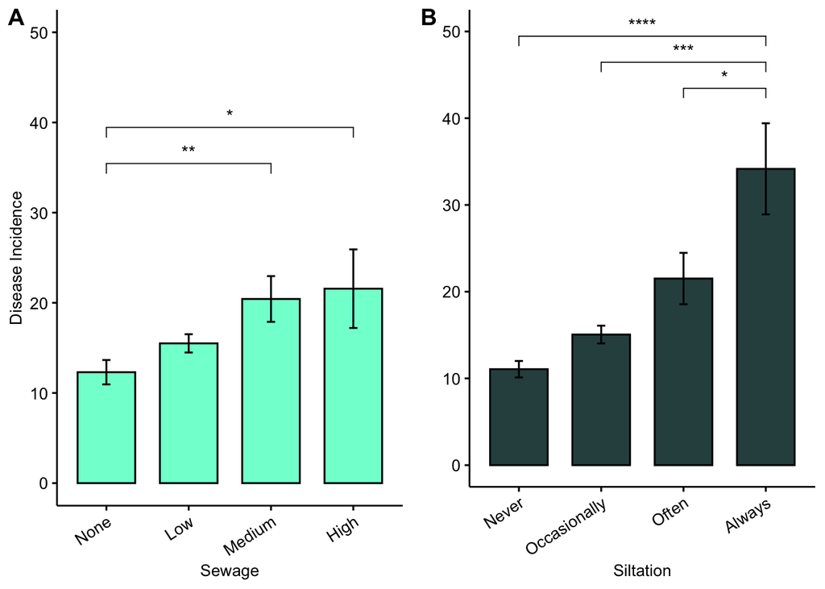

```r
# pared down version of graph for graphical abstract
ggarrange(sewage_plot_2, siltation_plot_2, ncol = 2, nrow = 1,
          labels = c("A", "B"))
```

Part 2: Impact of Distance to Nearest Population on Coral Bleaching & Disease

```r
# bleaching & distance
# first remove rows with no data for distance_to_nearest_popn_km using subset()
coral_distance_bleached <- bleached_coral %>%
  subset(distance_to_nearest_popn_km!="")

# create a linear model for distance and bleaching using lm()
lm_distance_bleached <- lm(bleaching_percent_pop ~ distance_to_nearest_popn_km,
                           data = coral_distance_bleached)
summary(lm_distance_bleached)
```

```
##
## Call:
## lm(formula = bleaching_percent_pop ~ distance_to_nearest_popn_km,
##     data = coral_distance_bleached)
##
## Residuals:
##     Min      1Q  Median      3Q     Max
## -13.947 -12.926  -9.924   3.075  85.076
##
## Coefficients:
##                              Estimate Std. Error t value Pr(>|t|)
## (Intercept)                 1.492e+01  3.831e-01  38.953   <2e-16 ***
## distance_to_nearest_popn_km 3.256e-04  8.972e-04   0.363    0.717
## ---
## Signif. codes:  0 '***' 0.001 '**' 0.01 '*' 0.05 '.' 0.1 ' ' 1
##
## Residual standard error: 20.4 on 2848 degrees of freedom
## Multiple R-squared:  4.625e-05,  Adjusted R-squared:  -0.0003049
## F-statistic: 0.1317 on 1 and 2848 DF,  p-value: 0.7167
```

```r
# correlation coefficient for distance and bleaching using cor()
cor(coral_distance_bleached$bleaching_percent_pop,
    coral_distance_bleached$distance_to_nearest_popn_km, method="pearson")
```

```
## [1] 0.006800657
```

```r
# disease & distance
# now remove rows with no data for distance_to_nearest_popn_km using subset()
coral_distance_disease <- diseased_coral %>%
  subset(distance_to_nearest_popn_km!="")

# create a linear model for distance and disease using lm()
lm_distance_disease <- lm(disease_count ~ distance_to_nearest_popn_km,
                          data = coral_distance_disease)
summary(lm_distance_disease)
```

```
##
## Call:
## lm(formula = disease_count ~ distance_to_nearest_popn_km, data = coral_distance_disease)
##
## Residuals:
##     Min      1Q  Median      3Q     Max
## -14.438 -13.437 -10.437   4.563  94.563
##
## Coefficients:
##                               Estimate Std. Error t value Pr(>|t|)
## (Intercept)                 15.4377142  0.7200372  21.440   <2e-16 ***
## distance_to_nearest_popn_km -0.0001609  0.0014128  -0.114    0.909
## ---
## Signif. codes:  0 '***' 0.001 '**' 0.01 '*' 0.05 '.' 0.1 ' ' 1
##
## Residual standard error: 21.66 on 907 degrees of freedom
## Multiple R-squared:  1.431e-05,  Adjusted R-squared:  -0.001088
## F-statistic: 0.01298 on 1 and 907 DF,  p-value: 0.9093
```

```r
# correlation coefficient for distance and disease using cor()
cor(coral_distance_disease$disease_count,
    coral_distance_disease$distance_to_nearest_popn_km, method="pearson")
```

```
## [1] -0.00378243
```

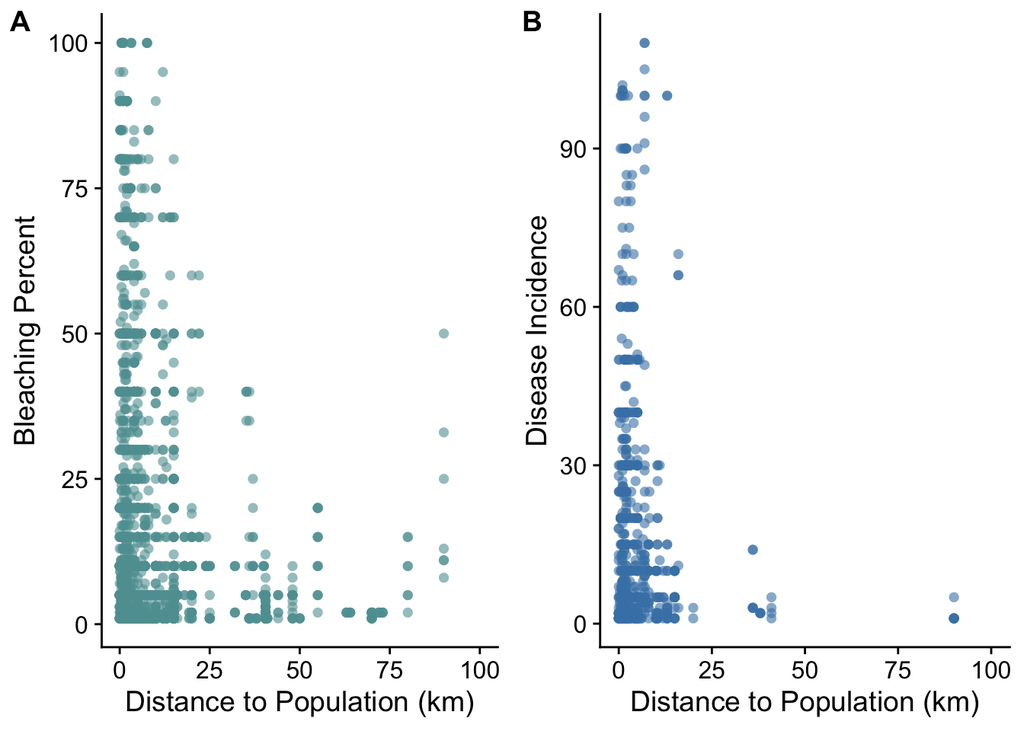

```r
# visualizing the relationship between distance and bleaching with ggplot()
# and set alpha to visualize density at each points
distance_bleaching_plot <- ggplot(coral_distance_bleached) +
        geom_point(aes(x=distance_to_nearest_popn_km, y=bleaching_percent_pop),
             shape = 16, color = "cadetblue", alpha = 0.6) +
        xlim(0, 100) +
        labs(x = "Distance to Population (km)",
             y = "Bleaching Percent") +
        theme_cowplot()

distance_disease_plot <- ggplot(coral_distance_disease) +
        geom_point(aes(x=distance_to_nearest_popn_km, y=disease_count),
             shape = 16, color = "steelblue", alpha = 0.6) +
        xlim(0, 100) +
        labs(x = "Distance to Population (km)",
             y = "Disease Incidence") +
        theme_cowplot()

ggarrange(distance_bleaching_plot, distance_disease_plot, ncol=2, nrow=1,
          labels = c("A", "B"))
```

```r
# this will be Figure 4 in the Science report
```

**Figure 4: Coral Health and Distance to Nearest Population.** Linear regression revealed no statistically significant relationship between distance to population and either coral bleaching (t(2848) = 0.363, p = 0.717) or disease incidence (t(907) = –0.114, p = 0.909). Darker dots indicate more data at those points.